# Machine Learning Project

Adnan

8/29/2019

## Background and Goal

Using devices such as Jawbone Up, Nike FuelBand, and Fitbit it is now possible to collect a large amount of data about personal activity relatively inexpensively. These type of devices are part of the quantified self movement - a group of enthusiasts who take measurements about themselves regularly to improve their health, to find patterns in their behavior, or because they are tech geeks. One thing that people regularly do is quantify how much of a particular activity they do, but they rarely quantify how well they do it. In this project, your goal will be to use data from accelerometers on the belt, forearm, arm, and dumbell of 6 participants. They were asked to perform barbell lifts correctly and incorrectly in 5 different ways. More information is available from the website here: http://groupware.les.inf.puc-rio.br/har (see the section on the Weight Lifting Exercise Dataset).

The goal of this project is to predict the manner in which they did the exercise. This is the “classe” variable in the training set. We may use any of the other variables to predict with. We will create a report describing how we built our model, how we used cross validation, what we think the expected out of sample error is, and why we made the choices we did. We will also use our prediction model to predict 20 different test cases.

## Data Loading

```r
training_data <- read.csv('pml-training.csv',na.strings=c("NA","#DIV/0!",""))
testing_data <- read.csv('pml-testing.csv',na.strings=c("NA","#DIV/0!",""))
dim(training_data)
```

```
## [1] 19622   160
```

```r
dim(testing_data)
```

```
## [1]  20 160
```

## Data cleaning

The first step should always be data cleaning Lets remove the columns that has all NAs as they can impact our analysis later on

```r
training_data <- training_data [colSums(!is.na(training_data)) > 0]
testing_data <- testing_data [colSums(!is.na(testing_data)) > 0]
dim(training_data)
```

```
## [1] 19622   154
```

```r
dim(testing_data)
```

```
## [1] 20 60
```

Next we can remove the columns that shouldnt be counted in machine algorithm. From the column names we know that first 7 columns shouldnt be counted in our algorithms as they are either ids, timestamps etc and are not meaningful data for our outcome

```r
training_data <- training_data[,-c(1:7)]
testing_data <- testing_data[,-c(1:7)]
dim(training_data)
```

```
## [1] 19622   147
```

```r
dim(testing_data)
```

```
## [1] 20 53
```

Next we can use nearZeroValue function remove columns that have almost zero variance or in other words remove columns that have no significant impact on the outcome

```r
library(caret)
nzv_col_tr <-nearZeroVar(training_data,saveMetrics = TRUE)
nzv_col_te <-nearZeroVar(testing_data,saveMetrics = TRUE)

training_data <- training_data[,nzv_col_tr$nzv == "FALSE"]
testing_data <- testing_data[,nzv_col_te$nzv == "FALSE"]
dim(training_data)
```

```
## [1] 19622   118
```

```r
dim(testing_data)
```

```
## [1] 20 53
```

## Harmonizing Column Variables

Lets make sure that both training and testing data sets have same variables being used in order to get reliable results

```r
classe <- training_data[,'classe']
training_data <- training_data[,colnames(training_data) %in% colnames(testing_data)]
training_data<- cbind(training_data,classe)
training_data$classe <- as.factor(training_data$classe)
dim(training_data)
```

```
## [1] 19622    53
```

### Cross Validation

```r
#library(caret)
set.seed(1000)
Intrain <- createDataPartition(y=training_data$classe,p=0.70,list=F)
straining <- training_data[Intrain,]
stesting <- training_data[-Intrain,]
dim(straining)
```

```
## [1] 13737    53
```

```r
dim(stesting)
```

```
## [1] 5885   53
```

## Applying Machine Learning Algorithms

### Decision Tree

Lets first apply Decision Tree

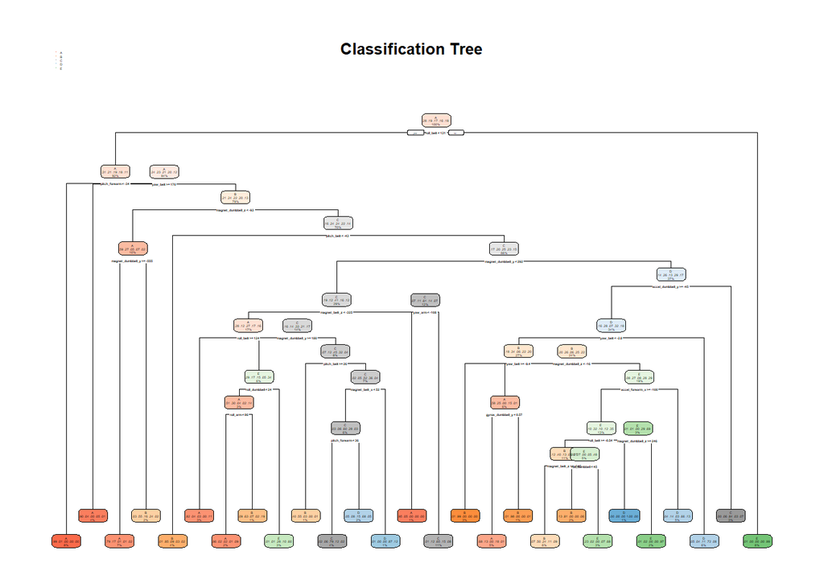

```r
library(rpart)
library(rpart.plot)
tree_model <- rpart(classe~.,data=straining, method='class')
rpart.plot(tree_model, main="Classification Tree")
```

```r
prediction1 <- predict(tree_model, stesting , type='class')
confusionMatrix(prediction1,stesting$classe)
```

```
## Confusion Matrix and Statistics
##
##           Reference
## Prediction    A    B    C    D    E
##          A 1461  150   10   57   50
##          B   88  814  138   68   71
##          C   14  111  790  161   83
##          D   44   56   47  643   82
##          E   67    8   41   35  796
##
## Overall Statistics
##
##                Accuracy : 0.7653
##                  95% CI : (0.7543, 0.7761)
##     No Information Rate : 0.2845
##     P-Value [Acc > NIR] : < 2.2e-16
##
##                   Kappa : 0.7028
##
##  Mcnemar's Test P-Value : < 2.2e-16
##
## Statistics by Class:
##
##                      Class: A Class: B Class: C Class: D Class: E
## Sensitivity            0.8728   0.7147   0.7700   0.6670   0.7357
## Specificity            0.9366   0.9231   0.9241   0.9535   0.9686
## Pos Pred Value         0.8455   0.6904   0.6816   0.7374   0.8405
## Neg Pred Value         0.9488   0.9309   0.9501   0.9360   0.9421
## Prevalence             0.2845   0.1935   0.1743   0.1638   0.1839
## Detection Rate         0.2483   0.1383   0.1342   0.1093   0.1353
## Detection Prevalence   0.2936   0.2003   0.1969   0.1482   0.1609
## Balanced Accuracy      0.9047   0.8189   0.8470   0.8102   0.8521
```

### Random Forest

Next lets what are the results we get with random forest

```r
library(randomForest)
forestmodel <- randomForest(classe~.,data= straining, na.action=na.roughfix, method="class")
prediction2 <- predict(forestmodel, stesting , type='class')
confusionMatrix(prediction2,stesting$classe)
```

```
## Confusion Matrix and Statistics
##
##           Reference
## Prediction    A    B    C    D    E
##          A 1671    6    0    0    0
##          B    3 1132    6    0    0
##          C    0    1 1018   11    0
##          D    0    0    2  952    3
##          E    0    0    0    1 1079
##
## Overall Statistics
##
##                Accuracy : 0.9944
##                  95% CI : (0.9921, 0.9961)
##     No Information Rate : 0.2845
##     P-Value [Acc > NIR] : < 2.2e-16
##
##                   Kappa : 0.9929
##
##  Mcnemar's Test P-Value : NA
##
## Statistics by Class:
##
##                      Class: A Class: B Class: C Class: D Class: E
## Sensitivity            0.9982   0.9939   0.9922   0.9876   0.9972
## Specificity            0.9986   0.9981   0.9975   0.9990   0.9998
## Pos Pred Value         0.9964   0.9921   0.9883   0.9948   0.9991
## Neg Pred Value         0.9993   0.9985   0.9984   0.9976   0.9994
## Prevalence             0.2845   0.1935   0.1743   0.1638   0.1839
## Detection Rate         0.2839   0.1924   0.1730   0.1618   0.1833
## Detection Prevalence   0.2850   0.1939   0.1750   0.1626   0.1835
## Balanced Accuracy      0.9984   0.9960   0.9949   0.9933   0.9985
```

### Conclusion

Forest Random is giving us much better Accuracy compared to decision tree. Therefore we will chose FR algorithm to apply on our testing data. Lets see below

```r
finalPrediction <- predict(forestmodel,testing_data, type='class')
finalPrediction
```

```
##  1  2  3  4  5  6  7  8  9 10 11 12 13 14 15 16 17 18 19 20
##  B  A  B  A  A  E  D  B  A  A  B  C  B  A  E  E  A  B  B  B
## Levels: A B C D E
```